# MACHINE BRUTE FORCE

Did you find Human Intelligence impressive? We are super impressed!

Well, the correct classification rates of *OurHIC* don’t quite compare to those by Google’s AI, which are in the 9x percent range. But we don’t have the kind of human resources Google has. Also, we are interested not just in the end, but also in the learning in the process.

The cool thing is: in building *OurHIC*, we learned lots about how people draw things. Like, you can have a whole pizza, or you can have just a slice. Or most bananas dutifully obey the law of gravity, but some mischievous ones don’t.

Now, switching gears, think about this: What if we put all that knowledge aside, as if we had never even looked at those images. Can a machine learning algorithm that does not benefit from our human visual perception (and is pretty much a black box) do a decent job at classifying [*Quick! Draw*](https://quickdraw.withgoogle.com/) images? We tried one that is popular for classifying images: a [convolutional neural network](https://en.wikipedia.org/wiki/Convolutional_neural_network). We name it *OurCNN* (not the news channel).

# *OurCNN* specs

## Input

32-by-32 image with black/white pixels

## Output

a label out of 31 edibles:

apple, asparagus, banana, birthday cake, blackberry, blueberry, bread, broccoli, cake, carrot, cookie, donut, grapes, hamburger, hot dog, ice cream, lollipop, mushroom, onion, peanut, pear, peas, pineapple, pizza, popsicle, potato, sandwich, steak, strawberry, string bean, watermelon

## Inside the box

### a. Architecture

2 convolution layers, each with the same structure:

- 32 filters of size 3-by-3, applied with padding
- ReLU activation followed by batch normalization

1 max-pooling layer

- filters of size 2-by-2
- followed by 30% dropout

1 dense layer

- 256 neurons
- ReLU activation followed by batch normalization
- 30% dropout

final layer

- 31 neurons (for probabilities of the 31 categories)
- softmax activation

### b. Optimization

loss: categorical cross-entropy

metric: accuracy

stochastic gradient descent:

- learning rate 0.001
- decay 1e-6
- momentum 0.9
- Nesterov accelerated

### c. Training

20 epochs

batch size 32

use 5000 images per type, split 4:1 into training and validation sets – a fraction of the 140-300K images available per type

pick the model at the epoch that combines *lowest validation loss* and *highest validation accuracy*, here epoch 12 – see the training history below

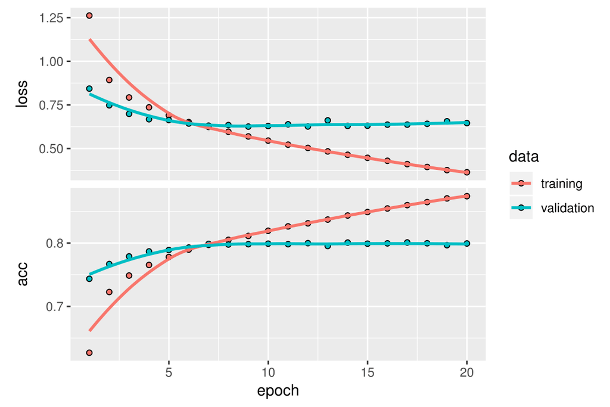

### d. Data

#### Data reduction

*Quick! Draw* images are black-and-white and come in 256-by-256 resolution. The data are stroke data, i.e., for each stroke of the pen, a series of points are stored such that if you connect them with straight segments, you recover the stroke.

*OurHIC* keeps the original resolution, but uses only the points that define the segments.

*OurCNN* uses those points and points between them, but reduces resolution to 32-by-32.

Here are the three data versions for a watermelon (piece), a sandwich, and a pear.

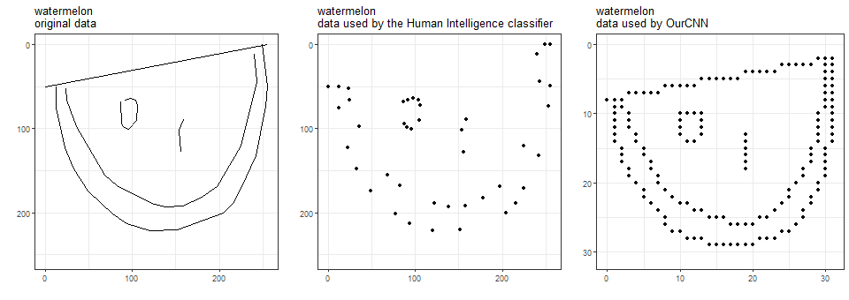

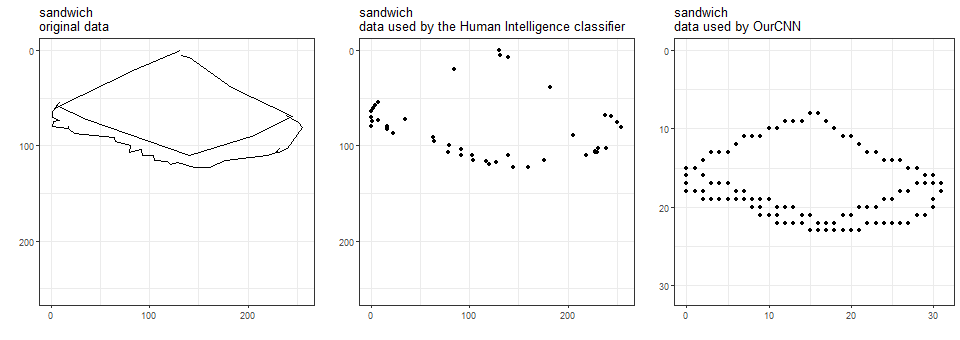

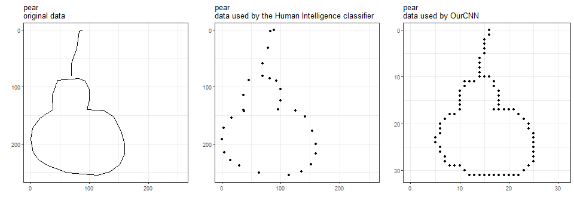

Hmm, it is now clear that we fed *OurHIC* less data than we did *OurCNN*.

Other data that neither classifiers use: time, country of origin, and also stroke sequence (relevant in a fascinating analysis of [how people draw circles](https://qz.com/994486/the-way-you-draw-circles-says-a-lot-about-you/)).

#### Data subsetting

*OurHIC* was trained on a random sample of images of each type, regardless of whether Google AI recognized what type it is.

*OurCNN* was trained on a random sample of images recognized by Google AI.

Here are two examples of Google-recognized and Google-unrecognized images.

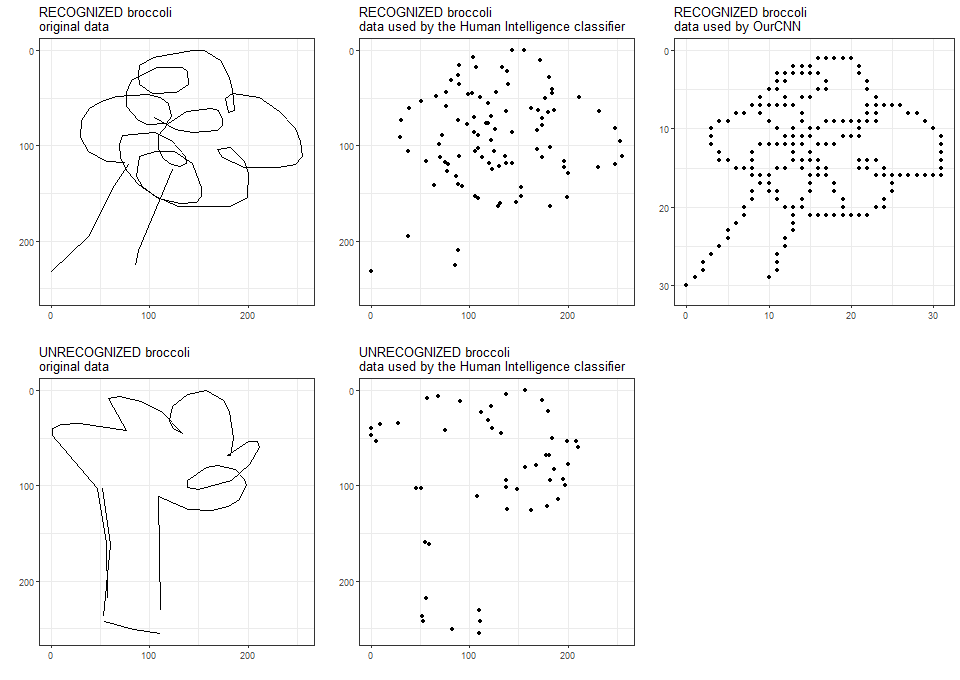

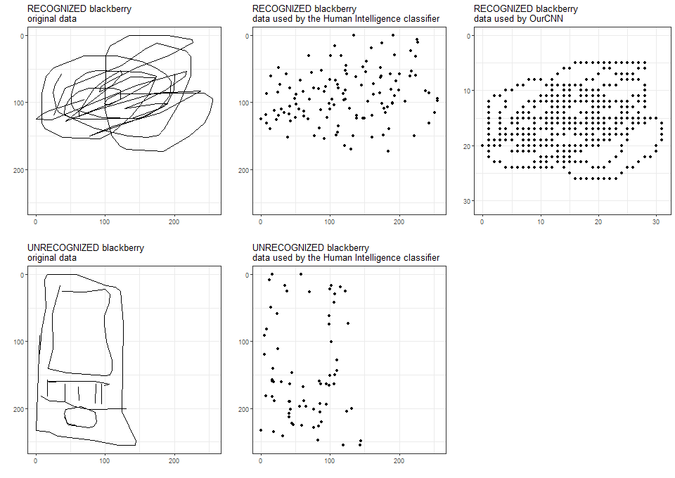

# *OurCNN* performance

We tested the performance of *OurCNN* on a set of images recognized by Google’s AI, a set of images not recognized, and a set of mixed images (the mix reflects the composition of the data). Each set includes 1000 images of each category of edibles.

## Classification probability matrices

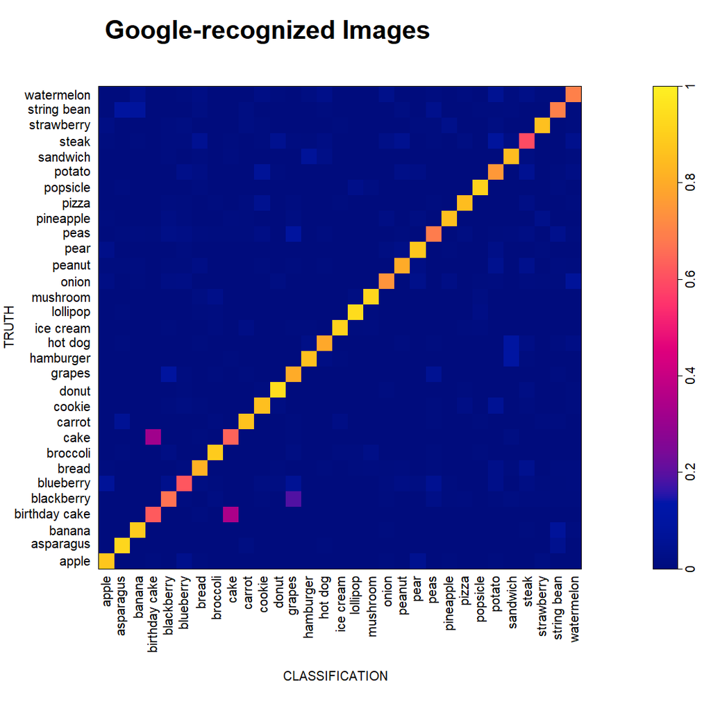

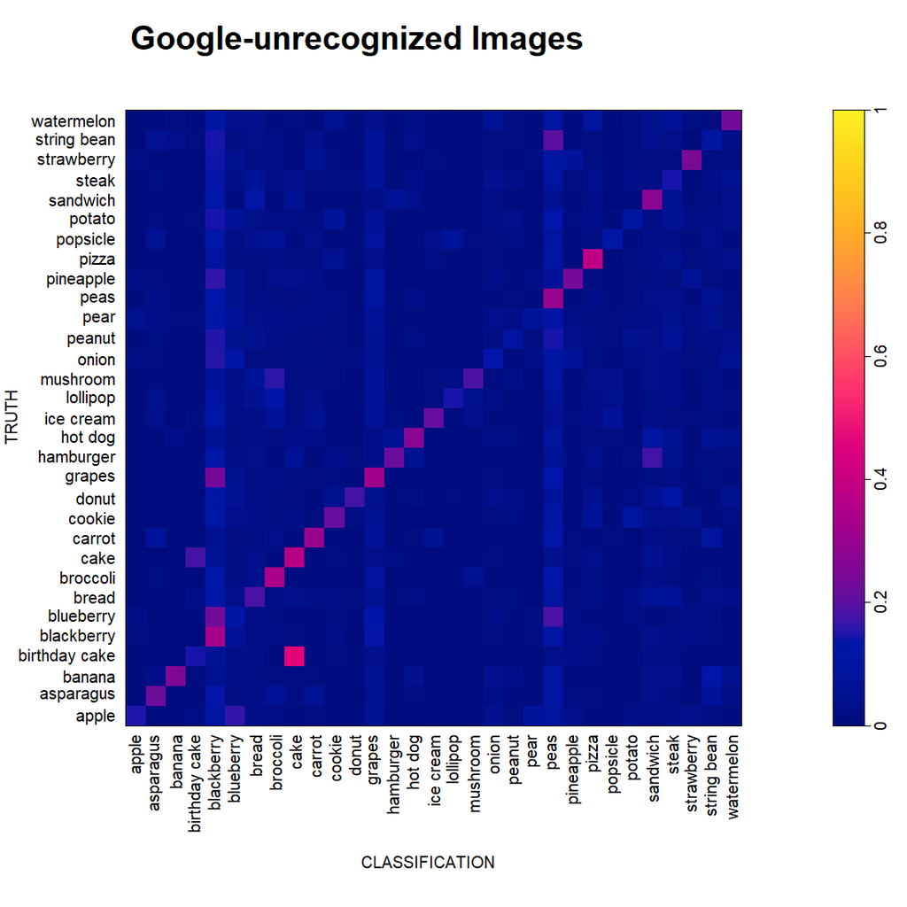

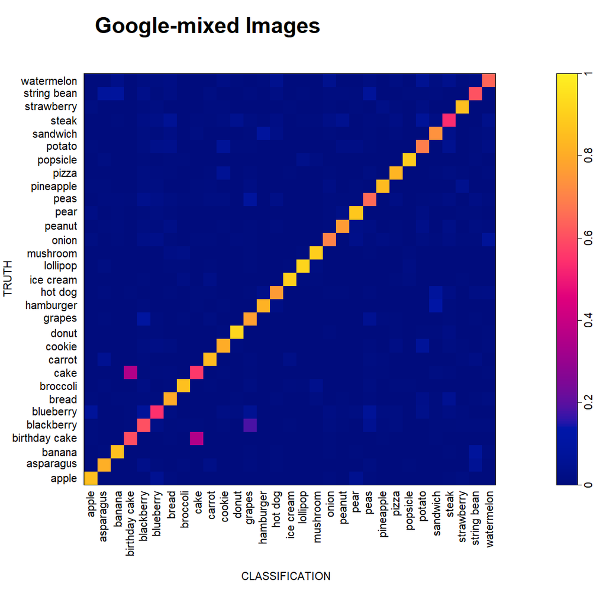